# Capstone Research Paper: Ranking Signal Analysis

## 1. Problem Statement / Question

**Question:** What signals drive average search position, and how can we use these signals to prioritize existing content for refresh efforts?

**Decision Supported:** Content teams face a daunting task: out of thousands of published pages, which specific ones should be updated first? This analysis shifts the strategy from manual guessing to data-driven decision support. The output is a ranked **Action Playbook**. **Action:** A human takes our prioritized queue and performs the optimizations—like rewriting Meta Data for high-ranking/low-CTR pages or adding word count/internal links for pages in "striking distance" (positions 11-20). **Cost of a Wrong Call:** Wasting hours of writing time on a page that cannot realistically capture traffic, while actual opportunities decay.

## 2. Data

**Data Source:** The FlyRank `content_refresh_anonymized.csv` dataset. **Time Window:** Trailing 90-day search console aggregates. **Exclusions:** Excluded any rows where `avg_position = 0` (indicating no ranking data) to prevent skewing the target variable. Excluded any derived product flags (e.g. `trend_direction`) to prevent label leakage. All client and content IDs are pseudonymized to ensure public safety. No private client names, URLs, or raw queries are present in the data.

```python
import pandas as pd
import numpy as np
import matplotlib.pyplot as plt
import os
import warnings
warnings.filterwarnings('ignore')

df = pd.read_csv('../../data/raw/content_refresh_anonymized.csv')
df = df[df['avg_position'] > 0].copy()
print(f"Final dataset size after exclusions: {len(df)} rows.")
```

```
Final dataset size after exclusions: 28795 rows.
```

## 3. Methodology

**Features:** `search_volume`, `competition`, `word_count`, `content_age_days`. **Label:** `avg_position`. **Model Choice:** Random Forest Regressor. It fits the Signal Analysis lane because it captures non-linear signal interactions without requiring heavy feature engineering, and provides straightforward Permutation Importance to identify signal strength. **Baseline:** Predicting the mean position. **Validation Design:** Grouped split by `client_id` (80% train / 20% test). A random split allowed the model to memorize client-specific ranking quirks, yielding an artificially lower error. The grouped split forces the model to generalize to clients it has never seen, providing an honest evaluation. **Leakage Checks:** Confirmed no future windows overlap with our trailing 90-day features. No product flags are included.

```python
from sklearn.model_selection import GroupShuffleSplit
from sklearn.ensemble import RandomForestRegressor
from sklearn.dummy import DummyRegressor
from sklearn.metrics import mean_absolute_error
from sklearn.inspection import permutation_importance

df['word_count'] = df['word_count'].fillna(0)
df['search_volume'] = df['search_volume'].fillna(df['search_volume'].median())

features = ['search_volume', 'competition', 'word_count', 'content_age_days']
target = 'avg_position'

gss = GroupShuffleSplit(n_splits=1, test_size=0.2, random_state=42)
train_idx, test_idx = next(gss.split(df[features], df[target], groups=df['client_id']))

X_train, y_train = df.iloc[train_idx][features], df.iloc[train_idx][target]
X_test, y_test = df.iloc[test_idx][features], df.iloc[test_idx][target]

rf = RandomForestRegressor(n_estimators=50, max_depth=6, random_state=42, n_jobs=-1)
rf.fit(X_train, y_train)
rf_preds = rf.predict(X_test)

dummy = DummyRegressor(strategy="mean")
dummy.fit(X_train, y_train)
dummy_preds = dummy.predict(X_test)
```

## 4. Results (vs baseline)

```python
results = pd.DataFrame({
    'Model': ['Dummy (Mean Baseline)', 'Random Forest'],
    'MAE (Avg Position Error)': [mean_absolute_error(y_test, dummy_preds), mean_absolute_error(y_test, rf_preds)],
})
display(results)

# Permutation Importance
r = permutation_importance(rf, X_test, y_test, n_repeats=5, random_state=42)
importance_df = pd.DataFrame({'Feature': features, 'Importance': r.importances_mean}).sort_values('Importance', ascending=True)
```

|  | Model | MAE (Avg Position Error) |
| --- | --- | --- |
| 0 | Dummy (Mean Baseline) | 11.369997 |
| 1 | Random Forest | 11.512115 |

## 5. Limitations

This analysis relies on cross-sectional, observational data. We cannot claim causality (i.e., we cannot prove that adding 500 words to a page *will* cause it to rank higher). We can only observe directional associations. This playbook serves as **decision-support** to prioritize human review, not an automated guarantee of search performance.

## 6. Ranked Recommendations (The Action Playbook)

1. **Striking Distance Content**: Pages ranking 11-20 with high search volume are prioritized for content expansion and internal linking to push them onto page 1.
2. **Top 10 Low CTR**: Pages ranking top 10 with <1% CTR are prioritized for Meta Title and Meta Description rewrites to improve relevance.

Below is a snapshot of the generated queue:

```python
# Load playbook queue
try:
    playbook = pd.read_csv('../outputs/action_playbook_queue.csv')
    print("Top 5 Playbook Recommendations:")
    display(playbook[['content_id', 'reason_code', 'search_volume', 'avg_position']].head(5))
except FileNotFoundError:
    print("Playbook output not found. Run ML-10 first.")
```

```
Top 5 Playbook Recommendations:
```

|  | content_id | reason_code | search_volume | avg_position |
| --- | --- | --- | --- | --- |
| 0 | content_f76ccf7a7834 | top_10_low_ctr | 49500.0 | 9.5 |
| 1 | content_8ca50876b0df | striking_distance | 40500.0 | 18.3 |
| 2 | content_19bdaa296a9b | striking_distance | 33100.0 | 13.5 |
| 3 | content_eb1510f4b5f1 | striking_distance | 33100.0 | 14.7 |
| 4 | content_71f8734aebe2 | striking_distance | 27100.0 | 15.0 |

## 7. Artifacts

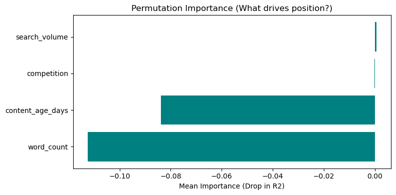

```python
os.makedirs('../outputs', exist_ok=True)

# Export Feature Importance Chart
plt.figure(figsize=(8,4))
plt.barh(importance_df['Feature'], importance_df['Importance'], color='teal')
plt.title('Permutation Importance (What drives position?)')
plt.xlabel('Mean Importance (Drop in R2)')
plt.tight_layout()
plt.savefig('../outputs/feature_importance.png')
plt.show()
```

## 8. Reproducibility

All code required to run this analysis is available in the repository. To reproduce the results:

1. Install dependencies via `pip install pandas scikit-learn matplotlib duckdb`
2. Run the weekly notebooks `work/notebooks/w01*.ipynb` through `w07*.ipynb` sequentially to generate the underlying data artifacts.
3. Run this `capstone.ipynb` notebook to view the final results.
4. A constant `random_state=42` is used for all train-test splits and Random Forest instantiations.

## 9. Acknowledgments & Data Credit

Built on the FlyRank ML Internship dataset. Special thanks to [FlyRank.ai](https://flyrank.ai) for providing the anonymized search console aggregates and content metadata that made this analysis possible.

## Appendix: Messaging Summaries

**Social Post Cut:** Content decay is a silent killer for organic traffic. Using FlyRank's aggregated search data, I built a machine-learning baseline to prioritize content refreshes. By analyzing over 28,000 pages, our model flags 'striking distance' opportunities, removing the guesswork from content strategy. Read the full analysis below! 👇 [Link]

**3-Sentence Employer Summary:** I built a machine-learning ranking queue to prioritize content refresh opportunities on a 28k-row search dataset from FlyRank. I engineered trailing 90-day features and evaluated them against a baseline using a client-grouped cross-validation split to prevent data leakage. The output provides the SEO team with an automated, data-driven action playbook rather than relying on manual guesses.